# Merger

### Extracting necessary information and cleaning.

We begin by importing the necessary libraries.

```r
library(dplyr)
library(tidyr)
library(e1071)   # for the SVM classifier
library(mice)    # for imputation using chained equation
```

First, we standardize the datasets so that they only contain information that goes into classifying. To this end, choose the following columns from their corresponding datasets.  
FE: name, age, sex, race, dateDMY, address, city, state, zip, county, year  
MPV: Victim’s name, Victim’s age, Victim’s gender, Victim’s race, Date of injury, address, city, state, zip code, county  
KBP: date_format, deceased_name, deceased_age, gender, race, state

```r
d1 <- fe.clean[c(1:4, 6:11, 22)]
d2 <- mpv[c(1:4, 6:11)]
d3 <- kbp[c(3, 8, 9, 10, 11, 15)]
```

Add row numbers columns, which shall be used in merging later.

```r
d1$parent_id <- seq.int(nrow(fe.clean))
d2$parent_id <- seq.int(nrow(mpv))
d3$parent_id <- seq.int(nrow(kbp))
```

Only keep the years in the intersection.

```r
d1 <- dplyr::filter(d1, d1$year >= 2013)
```

Clean up the name column, and add an **aka** column.

```r
# separate
d1 <- dplyr::filter(d1, d1$`name` != "Name withheld by police")
d1 <- tidyr::separate(d1, col = "name", into = c("name", "aka"), sep = " aka | or | transitioning from ")
```

```
Expected 2 pieces. Missing pieces filled with `NA` in 7681 rows [1, 2, 3, 4, 5, 6, 7, 8, 9, 10, 11, 12, 13, 14, 15, 16, 17, 18, 19, 20, ...].
```

```r
d2 <- dplyr::filter(d2, d2$`Victim's name` != "Name withheld by police")
d2 <- tidyr::separate(d2, col = "Victim's name", into = c("Victim's name", "aka"), sep = " aka | or | transitioning from ")
```

```
Expected 2 pieces. Missing pieces filled with `NA` in 5201 rows [1, 2, 3, 4, 5, 6, 7, 8, 9, 10, 11, 12, 13, 14, 15, 16, 17, 18, 19, 20, ...].
```

```r
# remove empty
d3$deceased_name <- as.character(lapply(d3$deceased_name, function(x) replace(x, x == "", NA)))
# ....Format names to remove . and \" \" (non-alpha)....
d1$name <- gsub("[^[:alnum:] ]", "", d1$name)
d2$`Victim's name` <- gsub("[^[:alnum:] ]", "", d2$`Victim's name`)
```

Standardize race.

```r
table(d1$race)
```

```
 African-American/Black  Asian/Pacific Islander European-American/White         Hispanic/Latino          Middle Eastern
                   2085                     130                    3456                    1268                      17
Native American/Alaskan        Race unspecified
                    112                     653
```

```r
table(d2$`Victim's race`)
```

```
           Asian            Black         Hispanic  Native American Pacific Islander     Unknown race            White
              92             1428              880               63               23              388             2333
```

```r
table(d3$race)
```

```
        A    B    I    L    O   PI    W
   1   79 1481  129  830   31   28 2445
```

```r
# replace Race unspecified and Unknown race with NA
d1$race <- lapply(d1$race, function(x) replace(x, grepl("Race unspecified", x), NA))
d2$`Victim's race` <- lapply(d2$`Victim's race`, function(x) replace(x, grepl("Unknown race", x), NA))
# change the format of race for d1
d1$race <- lapply(d1$race, function(x) replace(x, grepl("African-American/Black", x), "Black"))
d1$race <- lapply(d1$race, function(x) replace(x, grepl("European-American/White", x), "White"))
d1$race <- lapply(d1$race, function(x) replace(x, grepl("Hispanic/Latino", x), "Hispanic"))
d1$race <- lapply(d1$race, function(x) replace(x, grepl("Native American/Alaskan", x), "Native American"))
d1$race <- as.character(d1$race)
d2$`Victim's race` <- as.character(d2$`Victim's race`)
# change the format of race for d3
d3$race <- lapply(d3$race, function(x) replace(x, grepl("\\bA\\b", x), "Asian/Pacific Islander"))
d3$race <- lapply(d3$race, function(x) replace(x, grepl("\\bB\\b", x), "Black"))
d3$race <- lapply(d3$race, function(x) replace(x, grepl("\\bI\\b", x), "Native American"))
d3$race <- lapply(d3$race, function(x) replace(x, grepl("\\bL\\b", x), "Hispanic"))
d3$race <- lapply(d3$race, function(x) replace(x, grepl("\\bO\\b", x), NA))
d3$race <- lapply(d3$race, function(x) replace(x, grepl("\\bPI\\b", x), "Asian/Pacific Islander"))
d3$race <- lapply(d3$race, function(x) replace(x, grepl("\\bW\\b", x), "White"))
d3$race <- as.character(d3$race)
table(d1$race)
```

```
Asian/Pacific Islander                  Black               Hispanic         Middle Eastern        Native American                  White
                   130                   2085                   1268                     17                    112                   3456
```

```r
table(d2$`Victim's race`)
```

```
           Asian            Black         Hispanic  Native American Pacific Islander            White
              92             1428              880               63               23             2333
```

```r
table(d3$race)
```

```
                       Asian/Pacific Islander                  Black               Hispanic        Native American                  White
                     1                    107                   1481                    830                    129                   2445
```

Moving on to age.

```r
d2$`Victim's age` <- lapply(d2$`Victim's age`, function(x) replace(x, grepl("Unknown", x), NA))
d2$`Victim's age` <- as.character(d2$`Victim's age`)
d3$deceased_age <- as.character(d3$deceased_age)
```

Then sex.

```r
d1$sex <- as.character(lapply(d1$sex, function(x) replace(x, grepl("NULL", x), NA)))
d2$`Victim's gender` <- as.character(lapply(d2$`Victim's gender`, function(x) replace(x, grepl("Unknown", x), NA)))
d3$gender <- lapply(d3$gender, function(x) replace(x, grepl("F", x), "Female"))
d3$gender <- lapply(d3$gender, function(x) replace(x, grepl("M", x), "Male"))
d3$gender <- lapply(d3$gender, function(x) replace(x, grepl("T", x), "Transgender"))
d3$gender <- as.character(d3$gender)
```

Finally, date.

```r
d1$dateDMY <- as.character(strptime(d1$dateDMY, "%m/%d/%Y"))
d2$`Date of injury resulting in death (month/day/year)` <- as.character(strptime(d2$`Date of injury resulting in death (month/day/year)`, format = "%Y-%m-%d"))
d3$date_format <- as.character(strptime(d3$date_format, "%Y-%m-%d"))
```

### Now we are ready to train the classifier for d1 vs. d2 and predict off it.

Preapre the comparison weights.

```r
# ....start computing the comparison weights....
# block by address
cmp.tmp <- RecordLinkage::compare.linkage(as.data.frame(d1[c(1, 3:11)]), as.data.frame(d2[c(1, 3:11)]), strcmp = TRUE, blockfld = c(6))[[3]]
# block by name
cmp.tmp2 <- RecordLinkage::compare.linkage(as.data.frame(d1[c(1, 3:11)]), as.data.frame(d2[c(1, 3:11)]), strcmp = TRUE, blockfld = c(1))[[3]]
# block by zip
cmp.tmp3 <- RecordLinkage::compare.linkage(as.data.frame(d1[c(1, 3:11)]), as.data.frame(d2[c(1, 3:11)]), strcmp = TRUE, blockfld = c(9))[[3]]
# block by date
cmp.tmp4 <- RecordLinkage::compare.linkage(as.data.frame(d1[c(1, 3:11)]), as.data.frame(d2[c(1, 3:11)]), strcmp = TRUE, blockfld = c(5))[[3]]
cmp <- unique(rbind(cmp.tmp, cmp.tmp2), by = c("id1", "id2"))
cmp <- unique(rbind(cmp, cmp.tmp3), by = c("id1", "id2"))
cmp <- unique(rbind(cmp, cmp.tmp4), by = c("id1", "id2"))
```

Imputate the missing values.

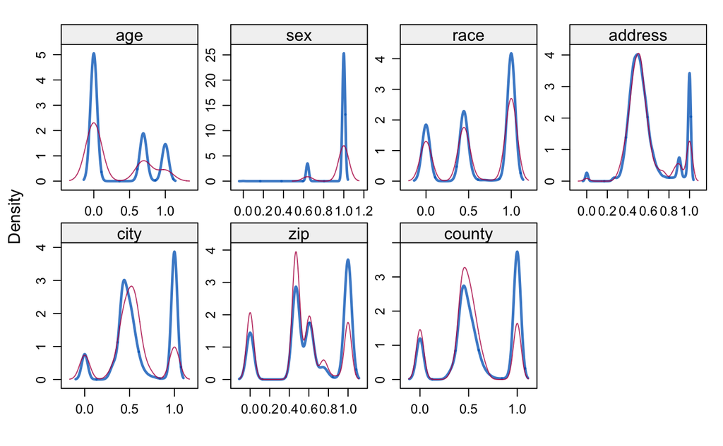

```r
# knnOutput <- knnImputation(cmp[c(-1, -2, -13)])
imp <- mice(cmp[-13], m = 1, maxit = 10)
densityplot(imp)
```

```r
knnOutput <- complete(imp)[c(-1, -2)]
knnOutput$id1 <- cmp$id1
knnOutput$id2 <- cmp$id2
```

Take an average over the various components of the address, and remove unecessary fields.

```r
knnOutput <- transform(knnOutput, new = (address + city + state + zip + county) / 5)
knnOutput <- knnOutput[c(-12:-6)]
```

Sort the comparison weights and filter matches and non-matches.

```r
# ....Sort and filter matches and non-matches....
one <- c(1, 1, 1, 1, 1, 1)
zero <- c(0, 0, 0, 0, 0, 0)
mat <- as.matrix(knnOutput)
knnOutput$dist <- t(pracma::distmat(one, mat))[,1]
knnOutput$dist2 <- t(pracma::distmat(zero, mat))[,1]
# order the pairs by distance from one
cmp.tmp6 <- knnOutput[order(knnOutput$dist),]
# seed matches
matches <- dplyr::filter(cmp.tmp6, dist <= 0.30)
# seed non-matches
# estimation ratio (true matches:true non-matches) r = 4865/(32696-4865) = 0.175
# order the pairs by distance from zero
cmp.tmp7 <- knnOutput[order(knnOutput$dist2),]
nonmatches <- cmp.tmp7[1:15000,]
# should be empty
dim(dplyr::intersect(matches[1:2], nonmatches[1:2]))
```

```
[1] 0 2
```

Prepare the training data from seed created above and train the model.

```r
matches$class <- "match"
nonmatches$class <- "nonmatch"
train.data <- rbind(matches, nonmatches)[c(-7, -8)]
svm.model <- svm(class ~ ., data = train.data, type = "C-classification")
```

Plot the model using slicing.

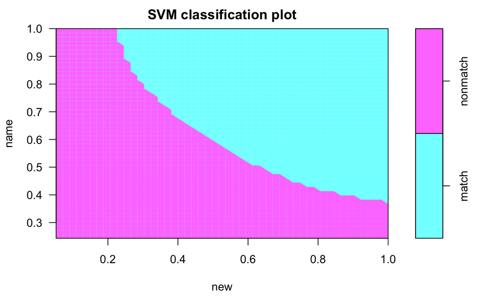

```r
plot(svm.model, data = train.data, name ~ new, slice = list(age = 1, sex = 1, race = 1, dateDMY = 1))
```

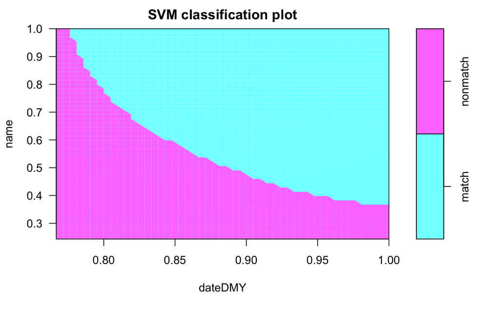

```r
plot(svm.model, data = train.data, name ~ dateDMY, slice = list(age = 1, sex = 1, race = 1, new = 1))
```

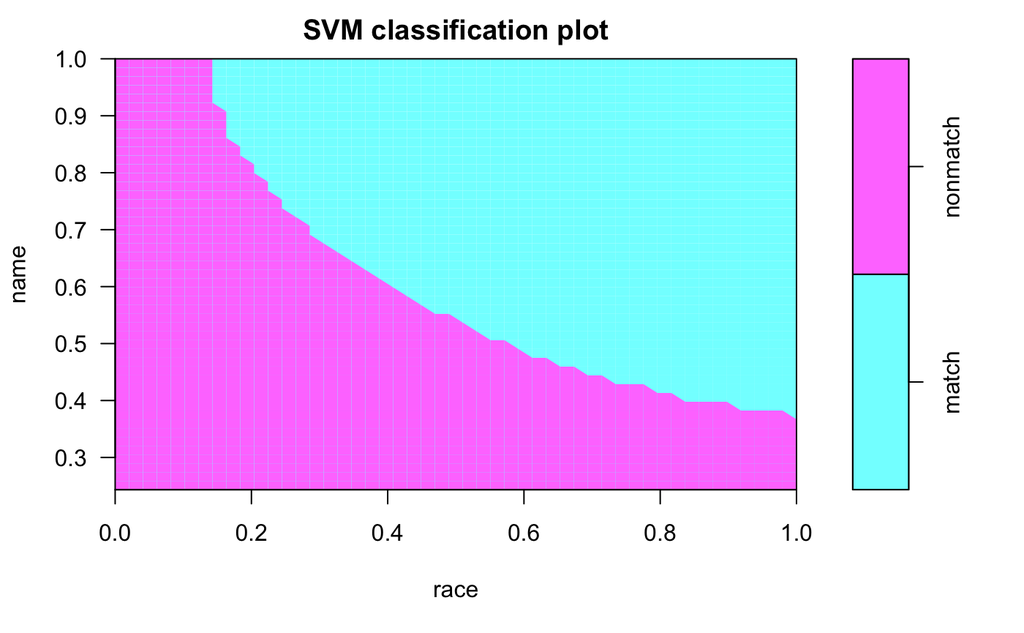

```r
plot(svm.model, data = train.data, name ~ race, slice = list(age = 1, sex = 1, new = 1, dateDMY = 1))
```

Predict and label the match number in d2 for matching cases, and “nonmatching” for other cases.

```r
test <- knnOutput[c( -7,-8)]
prediction <- predict(svm.model, test)
table(prediction)
```

```
prediction
   match nonmatch
    5239    27457
```

```r
prediction <- cbind(knnOutput, as.data.frame(prediction))
prediction$id1 <- cmp$id1
prediction$id2 <- cmp$id2
match.pred <- dplyr::filter(prediction, prediction == "match")
d2[,"matching"] <- NA
for (i in 1:length(d2[[1]])) {
  d2[i,]$matching <- match.pred[match(i, match.pred$id2),]$id1
}
for (i in 1:length(d2[[1]])) {
  if (is.na(d2[i, ]$matching)) {
    d2[i,]$matching <- "nonmatching"
  }
}
```

We are done predicting the classes for d1 vs. d2. Now, we do it for d1 vs. d3.

### In a very similar way, train the classifier for d1 vs. d3, and predict.

In an additional step, we remove NA name records.

```r
d3 <- filter(d3, !is.na(d3$deceased_name))
```

Prepare the comparison weights.

```r
# block by date
cmp.tmp <- RecordLinkage::compare.linkage(as.data.frame(d1[c(6, 1, 3, 4, 5, 9)]), as.data.frame(d3[-7]), strcmp = TRUE, blockfld = c(1))[[3]]
# block by name
cmp.tmp2 <- RecordLinkage::compare.linkage(as.data.frame(d1[c(6, 1, 3, 4, 5, 9)]), as.data.frame(d3[-7]), strcmp = TRUE, blockfld = c(2))[[3]]
cmp2 <- unique(rbind(cmp.tmp, cmp.tmp2), by = c("id1", "id2"))
```

Imputate the missing values.

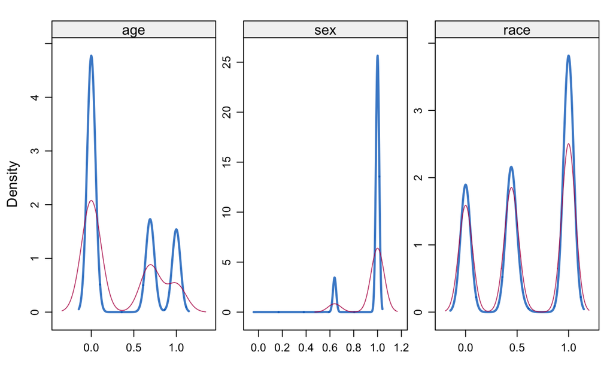

```r
# knnOutput2 <- knnImputation(cmp2[c(-1, -2, -9)])
imp <- mice(cmp2[-9], m = 1)
densityplot(imp)
```

```r
knnOutput2 <- complete(imp)[c(-1, -2)]
```

Sort the comparison weights and filter matches and non-matches.

```r
# ....Sort and filter matches and non-matches....
one <- c(1, 1, 1, 1, 1, 1)
zero <- c(0, 0, 0, 0, 0, 0)
mat <- as.matrix(knnOutput2)
knnOutput2$dist <- t(pracma::distmat(one, mat))[,1]
knnOutput2$dist2 <- t(pracma::distmat(zero, mat))[,1]
# order the pairs by distance from one
cmp.tmp6 <- knnOutput2[order(knnOutput2$dist),]
# seed matches
matches2 <- dplyr::filter(cmp.tmp6, dist <= 0.10)
# seed non-matches
# estimation ratio (true matches:true non-matches) r = 4865/(32696-4865) = 0.175
# order the pairs by distance from zero
cmp.tmp7 <- knnOutput2[order(knnOutput2$dist2),]
nonmatches2 <- cmp.tmp7[1:14500,]
```

Prepare the training data from seed created above and train the model.

```r
matches2$class <- "match"
nonmatches2$class <- "nonmatch"
train.data2 <- rbind(matches2, nonmatches2)[c(-7, -8)]
svm.model2 <- svm(class ~ ., data = train.data2, type = "C-classification")
```

Predict and label the match number in d3 for matching cases, and “nonmatching” for other cases.

```r
test2 <- knnOutput2[c( -7,-8)]
prediction2 <- predict(svm.model2, test2)
table(prediction2)
```

```
prediction2
   match nonmatch
    4966    23284
```

```r
prediction2 <- cbind(knnOutput2, as.data.frame(prediction2))
prediction2$id1 <- cmp2$id1
prediction2$id2 <- cmp2$id2
match.pred2 <- dplyr::filter(prediction2, prediction2 == "match")
d3[,"matching"] <- NA
for (i in 1:length(d3[[1]])) {
  d3[i,]$matching <- match.pred2[match(i, match.pred2$id2),]$id1
}
for (i in 1:length(d3[[1]])) {
  if (is.na(d3[i, ]$matching)) {
    d3[i,]$matching <- "nonmatching"
  }
}
```

### Evaluate and Analyze

Create a stratified sample.

```r
set.seed(5567)
tmp <- filter(d2, !is.na(matching))
tmp1 <- filter(tmp, matching == "nonmatching")
rand1 <- tmp1[sample(nrow(tmp1), 25), ]
tmp2 <- filter(tmp, matching != "nonmatching")
rand2 <- tmp2[sample(nrow(tmp2), 25), ]
tmp. <- filter(d3, !is.na(matching))
tmp3 <- filter(tmp., matching == "nonmatching")
rand3 <- tmp3[sample(nrow(tmp3), 25), ]
tmp4 <- filter(tmp., matching != "nonmatching")
rand4 <- tmp4[sample(nrow(tmp4), 25), ]
```

FE vs. MPV:

```
Sample stratified: 25 algorithm matches and 25 algorithm non-matches

                        Algorithm match           Algorithm non-match
        True match            25                            3
        True non-match        0                             22

Sensitivity: 0.89
Specificity: 1
Positive Predictive validity: 1
Negative Predictive validity: 0.88
```

FE vs. KBP:

```
Sample stratified: 25 algorithm matches and 25 algorithm non-matches

                        Algorithm match           Algorithm non-match
        True match            25                            1
        True non-match        0                             24

Sensitivity: 0.96
Specificity: 1
Positive Predictive validity: 1
Negative Predictive validity: 0.96
```

### Misc.

Exploring the prospect of merging.

```r
a <- filter(cmp2, is.na(race) & name == 1 & sex == 1 & age == 1 & state == 1 & dateDMY == 1)
in.FE <- nrow(filter(d1[unique(a$id1),], !is.na(race)))
in.KBP <- nrow(filter(d3[unique(a$id2),], !is.na(race)))
in.both <- nrow(filter(cmp2, race == 1 & name == 1 & sex == 1 & age == 1 & state == 1 & dateDMY == 1))
in.none <- nrow(a) - in.FE - in.KBP
```

On the data where everything matches perfectly, and **RACE** might be present or absent,

```
                                   KBP present             KBP NA

             FE present                2206                  243
             FE NA                      21                   135
```

```r
a <- filter(cmp2, is.na(sex) & name == 1 & race == 1 & age == 1 & state == 1 & dateDMY == 1)
in.FE <- nrow(filter(d1[unique(a$id1),], !is.na(sex)))
in.KBP <- nrow(filter(d3[unique(a$id2),], !is.na(gender)))
in.both <- nrow(filter(cmp2, race == 1 & name == 1 & sex == 1 & age == 1 & state == 1 & dateDMY == 1))
in.none <- nrow(a) - in.FE - in.KBP
```

On the data where everything matches perfectly, and **SEX** might be present or absent,

```
                                   KBP present             KBP NA

             FE present                2206                  0
             FE NA                      1                    0
```

```r
a <- filter(cmp2, is.na(age) & name == 1 & race == 1 & sex == 1 & state == 1 & dateDMY == 1)
in.FE <- nrow(filter(d1[unique(a$id1),], !is.na(age)))
in.KBP <- nrow(filter(d3[unique(a$id2),], !is.na(deceased_age)))
in.both <- nrow(filter(cmp2, race == 1 & name == 1 & sex == 1 & age == 1 & state == 1 & dateDMY == 1))
in.none <- nrow(a) - in.FE - in.KBP
```

On the data where everything matches perfectly, and **AGE** might be present or absent,

```
                                   KBP present             KBP NA

             FE present                2206                  10
             FE NA                      4                     2
```

### Merge.

Extract any information out of the merged datasets that you can.

```r
final <- fe.clean
b <- filter(d3, d3$matching != "nonmatching")
for (i in 1:nrow(b)) {
  j <- d1[b[i,]$matching,]$parent_id
  if (is.na(d1[b[i,]$matching,]$age) & !is.na(b[i,]$deceased_age)) {
    final[j,]$age <- b[i,]$deceased_age
  }
  if (is.na(d1[b[i,]$matching,]$sex) & !is.na(b[i,]$gender)) {
    final[j,]$sex <- b[i,]$gender
  }
  if (is.na(d1[b[i,]$matching,]$race) & !is.na(b[i,]$race)) {
    res <- b[i,]$race
    z <- res
    if (z == "Black") {
      res <- "African-American/Black"
    } else if (z == "Hispanic") {
      res <- "Hispanic/Latino"
    } else if (z == "White") {
      res <- "European-American/White"
    } else if (z == "Native American") {
      res <- "Native American/Alaskan"
    }
    final[j,]$race <- res
  }
  if (is.na(d1[b[i,]$matching,]$dateDMY) & !is.na(b[i,]$date_format)) {
    final[j,]$dateDMY <- b[i,]$date_format
  }
  if (is.na(d1[b[i,]$matching,]$state) & !is.na(b[i,]$state)) {
    final[j,]$state <- b[i,]$state
  }
}
```

```r
b <- filter(d2, d2$matching != "nonmatching")
for (i in 1:nrow(b)) {
  j <- d1[b[i,]$matching,]$parent_id
  if (is.na(d1[b[i,]$matching,]$age) & !is.na(b[i,]$`Victim's age`)) {
    final[j,]$age <- b[i,]$`Victim's age`
  }
  if (is.na(d1[b[i,]$matching,]$sex) & !is.na(b[i,]$`Victim's gender`)) {
    final[j,]$sex <- b[i,]$`Victim's gender`
  }
  if (is.na(d1[b[i,]$matching,]$race) & !is.na(b[i,]$`Victim's race`)) {
    res <- b[i,]$`Victim's race`
    z <- res
    if (z == "Black") {
      res <- "African-American/Black"
    } else if (z == "Hispanic") {
      res <- "Hispanic/Latino"
    } else if (z == "White") {
      res <- "European-American/White"
    } else if (z == "Native American") {
      res <- "Native American/Alaskan"
    } else if (z == "Asian") {
      res <- "Asian/Pacific Islander"
    } else if (z == "Pacific Islander") {
      res <- "Asian/Pacific Islander"
    }
    final[j,]$race <- res
  }
  if (is.na(d1[b[i,]$matching,]$dateDMY) & !is.na(b[i,]$`Date of injury resulting in death (month/day/year)`)) {
    final[j,]$dateDMY <- b[i,]$`Date of injury resulting in death (month/day/year)`
  }
  if (is.na(d1[b[i,]$matching,]$address) & !is.na(b[i,]$`Location of injury (address)`)) {
    final[j,]$address <- b[i,]$`Location of injury (address)`
  }
  if (is.na(d1[b[i,]$matching,]$city) & !is.na(b[i,]$`Location of death (city)`)) {
    final[j,]$city <- b[i,]$`Location of death (city)`
  }
  if (is.na(d1[b[i,]$matching,]$state) & !is.na(b[i,]$`Location of death (state)`)) {
    final[j,]$state <- b[i,]$`Location of death (state)`
  }
  if (is.na(d1[b[i,]$matching,]$zip) & !is.na(b[i,]$`Location of death (zip code)`)) {
    final[j,]$zip <- b[i,]$`Location of death (zip code)`
  }
  if (is.na(d1[b[i,]$matching,]$county) & !is.na(b[i,]$`Location of death (county)`)) {
    final[j,]$county <- b[i,]$`Location of death (county)`
  }
}
```

Fatten up the non-matching data and append it to final.

```r
b <- filter(d3, matching == "nonmatching")
for (i in 1:nrow(b)) {
  ent <- kbp[b[i,]$parent_id,]
  n <- strptime(ent$date_format, "%Y-%m-%d")
  d <- format(n, "%m/%d/%Y")
  res <- b[i,]$race
  z <- res
  if (!is.na(z)) {
    if (z == "Black") {
        res <- "African-American/Black"
      } else if (z == "Hispanic") {
        res <- "Hispanic/Latino"
      } else if (z == "White") {
        res <- "European-American/White"
      } else if (z == "Native American") {
        res <- "Native American/Alaskan"
      } else if (z == "Asian") {
        res <- "Asian/Pacific Islander"
      } else if (z == "Pacific Islander") {
        res <- "Asian/Pacific Islander"
      }
  }
  to.add <- data.frame("name" = b[i,]$deceased_name, "age" = b[i,]$deceased_age,
              "sex" = b[i,]$gender, "race" = res, "URLpic" = ent$fb_pic, "dateDMY" = d, "state" = b[i,]$state, "year" = year(n))
  suppressWarnings(final <- bind_rows(final, to.add))
}
```

Erase everything and save final.

```r
setwd("~/git/ffsg/Data/Merging/")
rm(list=setdiff(ls(), "final"))
save.image("./final.Rdata")
```